# Modelling the probability of zero sharks, one shark or more than one shark

Author

CBuelow

Published

11/25/24

We start by subsetting the shark abundance data to the coral triangle to develop the model and demonstrate the approach.

##### Subset, wrangle and visualise the data

Note that covariates are selected based on Klinard et al. (in prep) DAG. Continuous covariates are mean centered and scaled.

```r
# read in, wrangle and visualise the data
library(tidyverse)
library(GGally)
scale_2SD <- function(x) (x-mean(x))/(2*sd(x)) # function to mean center and scale continuous predictors (note dividing by 2 standard deviations (as recommended by Gelman))

dat <- read.csv('data/fpdat_final.csv') |>
  filter(region_name == "Coral Triangle") |>
  # separate fishing restrictions into categorical variables for each limit type
  separate(col = 'fishing_restrictions',
           into = c('limits1', 'limits2', 'limits3', 'limits4', 'limits5', 'limits6', 'limits7', 'limits8')) |>
  mutate(gear_limits = ifelse(limits1 == 'gear' | limits2 == 'gear' | limits3 == 'gear' | limits4 == 'gear' | limits5 == 'gear' | limits8 == 'gear', 1, 0),
         species_limits = ifelse(limits1 == 'species' | limits2 == 'species' | limits3 == 'species' | limits4 == 'species' | limits5 == 'species' | limits8 == 'species', 1, 0),
         catch_limits = ifelse(limits1 == 'bag' | limits2 == 'bag' | limits3 == 'bag' | limits4 == 'bag' | limits5 == 'bag' | limits8 == 'bag', 1, 0),
         effort_limits = ifelse(limits1 == 'effort' | limits2 == 'effort' | limits3 == 'effort' | limits4 == 'effort' | limits5 == 'effort' | limits8 == 'effort', 1, 0),
         size_limits = ifelse(limits1 == 'size' | limits2 == 'size' | limits3 == 'size' | limits4 == 'size' | limits5 == 'size' | limits8 == 'size', 1, 0),
         temporal_limits = ifelse(limits1 == 'temporal' | limits2 == 'temporal' | limits3 == 'temporal' | limits4 == 'temporal' | limits5 == 'temporal' | limits8 == 'temporal', 1, 0)) |>
  # select response and covariates of interest
  select(set_lat, set_long, set_id, reef_id, location_id, region_id, shark_maxn,
         mpa_present, mpa_age, mpa_area, mpa_compliance,
         gear_limits, species_limits, catch_limits, effort_limits, size_limits, temporal_limits,
         shark_protection_status, shark_sanctuary, HDI_2015, gov_effect_2016, population_2016, Grav_Total) |>   # make maxn an ordinal response, and the other categorical variables factors
  # put continuous covariates on same scale as binary by dividing by 2 standard deviations (as recommended by Gelman), also mean center to improve interpretation of coeffs in presence of interactions
  mutate(shark_maxn = factor(ifelse(shark_maxn > 1, 2, shark_maxn), order = T, levels = c('0','1','2')),
         mpa_compliance = ifelse(mpa_compliance == 'high', 1, 0),
         mpa_present = ifelse(mpa_present == 'yes', 1, 0),
         across(c(mpa_present:temporal_limits), ~ifelse(is.na(.), 0, .)),
         across(c(set_id:region_id, mpa_present, mpa_compliance:shark_sanctuary), factor),
         across(c(mpa_age, mpa_area, HDI_2015, gov_effect_2016, population_2016, Grav_Total), scale_2SD))
```

```r
head(dat)
```

```
    set_lat set_long set_id reef_id location_id region_id shark_maxn
1  4.582367 118.7754    979     402         100         2          0
2  4.582283 118.7731    980     402         100         2          0
3 -5.598950 122.4962  33238     493          93         2          2
4 -5.603340 122.4992  33239     493          93         2          2
5  4.634717 118.7525    341     402         100         2          0
6  4.636650 118.7473   1060     402         100         2          0
  mpa_present    mpa_age    mpa_area mpa_compliance gear_limits species_limits
1           1  0.1589754 -0.08214287              0           0              1
2           1  0.1589754 -0.08214287              0           0              1
3           0 -0.3008385 -0.15940109              0           0              0
4           0 -0.3008385 -0.15940109              0           0              0
5           1  0.1589754 -0.08214287              0           0              1
6           1  0.1589754 -0.08214287              0           0              1
  catch_limits effort_limits size_limits temporal_limits
```

[output cut: 20 more lines]

```r
summary(dat)
```

```
    set_lat           set_long          set_id        reef_id      location_id
 Min.   :-10.824   Min.   : 95.03   307    :   1   340    : 172   93     :975
 1st Qu.: -5.526   1st Qu.:116.03   341    :   1   493    : 154   100    :479
 Median :  2.720   Median :119.81   342    :   1   492    : 128   74     :307
 Mean   :  2.764   Mean   :122.43   343    :   1   402    :  95   95     :297
 3rd Qu.:  8.797   3rd Qu.:123.97   344    :   1   327    :  93   71     :180
 Max.   : 24.407   Max.   :158.32   345    :   1   200    :  86   117    :112
                                    (Other):2554   (Other):1832   (Other):210
 region_id shark_maxn mpa_present    mpa_age           mpa_area
 2:2560    0:2156     0:1568      Min.   :-0.3008   Min.   :-0.1594
           1: 257     1: 992      1st Qu.:-0.3008   1st Qu.:-0.1594
           2: 147                 Median :-0.3008   Median :-0.1594
                                  Mean   : 0.0000   Mean   : 0.0000
                                  3rd Qu.: 0.1172   3rd Qu.:-0.1219
                                  Max.   : 1.4130   Max.   : 2.5462

 mpa_compliance gear_limits species_limits catch_limits effort_limits
 0:2308         0:2242      0:2131         0:2421       0:2049
 1: 252         1: 318      1: 429         1: 139       1: 511





 size_limits temporal_limits shark_protection_status shark_sanctuary
 0:2421      0:2507          closed    : 545         0:2560
 1: 139      1:  53          open      : 985
                             restricted:1030




    HDI_2015        gov_effect_2016   population_2016      Grav_Total
 Min.   :-0.95029   Min.   :-0.9313   Min.   :-0.33561   Min.   :-0.31800
 1st Qu.:-0.05178   1st Qu.:-0.1286   1st Qu.:-0.28983   1st Qu.:-0.24757
 Median :-0.01412   Median :-0.1072   Median :-0.18187   Median :-0.16030
 Mean   : 0.00000   Mean   : 0.0000   Mean   : 0.00000   Mean   : 0.00000
 3rd Qu.: 0.24952   3rd Qu.: 0.1752   3rd Qu.: 0.05429   3rd Qu.:-0.01484
 Max.   : 1.13727   Max.   : 1.3816   Max.   : 1.72687   Max.   : 8.71097
```

**Note** that there are no shark sanctuaries in Coral triangle, so will not include as a covariate.

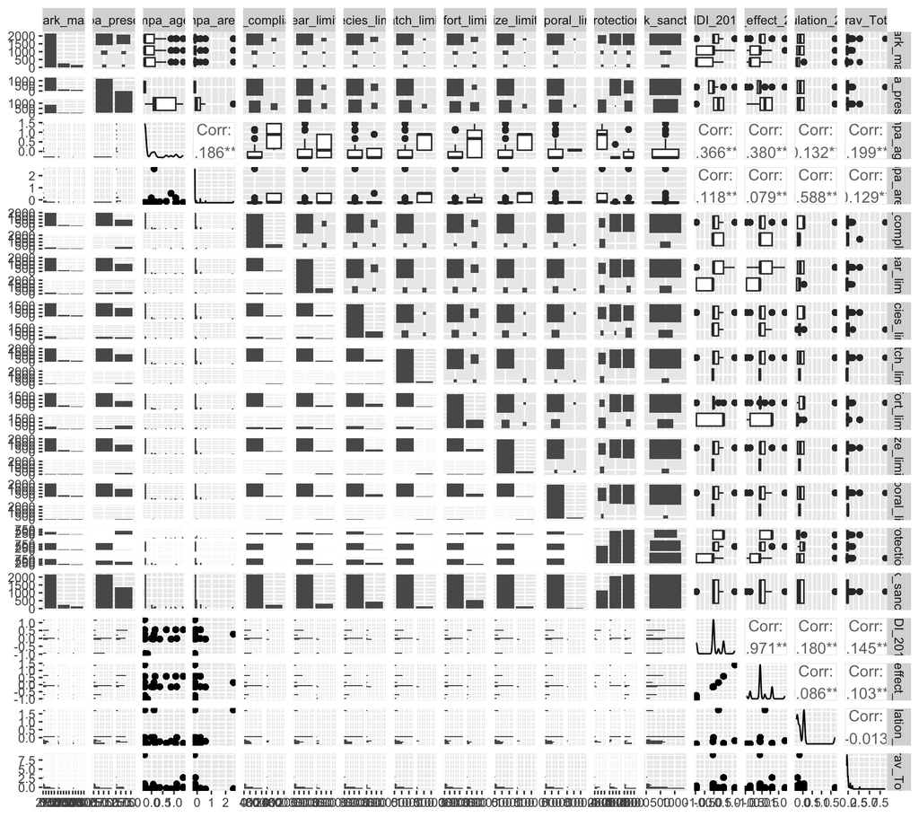

```r
ggpairs(select(dat, shark_maxn:Grav_Total))
```

##### Map the data

```r
library(sf)
library(tmap)
tmap_mode('view')

dat.sf <- dat |>
  st_as_sf(coords = c('set_long', 'set_lat'), crs = 4326)
qtm(dat.sf, dots.col = 'shark_protection_status')
```

[interactive chart not shown]

##### The model

We use a Bayesian multilevel, sequential ordinal regression to estimate the probability of encountering 0, 1 or >1 shark given covariates identified in a structural causal model (Klinard et al. *in prep*).

There are different classes of ordinal models determined by the process by which ordered categories are generated in the response variable of interest (e.g., continuous vs. sequential).

Encountering 0, 1, or more than 1 shark is a sequential rather than continuous categorisation process. It is sequential because we can only encounter more than 1 shark after we have encountered 1 shark, and we can only encounter 1 shark after we have encountered 0.

Therefore, instead of using a cumulative model that assumes a single latent continuous variable for the ordered categorical response (e.g., Likert response data), we instead use a sequential model that assumes there is a latent continuous variable for every each category in the ordinal response variable (e.g., 0, 1 or >1 sharks).

##### Prior predictive check

First check what we can set priors for.

```r
library(brms)
library(tidybayes)
library(rstan)
rstan_options(auto_write = TRUE)
options(mc.cores = parallel::detectCores())
```

```r
# what can we set priors for?
get_prior(shark_maxn ~  mpa_present + mpa_age + mpa_area + mpa_compliance +
             gear_limits + species_limits + catch_limits + effort_limits + size_limits + temporal_limits + HDI_2015 + gov_effect_2016 + population_2016 + shark_protection_status + Grav_Total + (1|location_id/reef_id/set_id), data = dat, family = sratio("cloglog"))
```

```
                prior     class                              coef
               (flat)         b
               (flat)         b                     catch_limits1
               (flat)         b                    effort_limits1
               (flat)         b                      gear_limits1
               (flat)         b                   gov_effect_2016
               (flat)         b                        Grav_Total
               (flat)         b                          HDI_2015
               (flat)         b                           mpa_age
               (flat)         b                          mpa_area
               (flat)         b                   mpa_compliance1
               (flat)         b                      mpa_present1
               (flat)         b                   population_2016
               (flat)         b       shark_protection_statusopen
               (flat)         b shark_protection_statusrestricted
               (flat)         b                      size_limits1
               (flat)         b                   species_limits1
               (flat)         b                  temporal_limits1
 student_t(3, 0, 2.5) Intercept
 student_t(3, 0, 2.5) Intercept                                 1
 student_t(3, 0, 2.5) Intercept                                 2
 student_t(3, 0, 2.5)        sd
 student_t(3, 0, 2.5)        sd
 student_t(3, 0, 2.5)        sd                         Intercept
 student_t(3, 0, 2.5)        sd
 student_t(3, 0, 2.5)        sd                         Intercept
 student_t(3, 0, 2.5)        sd
 student_t(3, 0, 2.5)        sd                         Intercept
                      group resp dpar nlpar lb ub       source
                                                       default
                                                  (vectorized)
                                                  (vectorized)
                                                  (vectorized)
                                                  (vectorized)
                                                  (vectorized)
                                                  (vectorized)
                                                  (vectorized)
                                                  (vectorized)
                                                  (vectorized)
                                                  (vectorized)
                                                  (vectorized)
                                                  (vectorized)
                                                  (vectorized)
                                                  (vectorized)
                                                  (vectorized)
                                                  (vectorized)
                                                       default
                                                  (vectorized)
                                                  (vectorized)
                                             0         default
                location_id                  0    (vectorized)
                location_id                  0    (vectorized)
        location_id:reef_id                  0    (vectorized)
        location_id:reef_id                  0    (vectorized)
 location_id:reef_id:set_id                  0    (vectorized)
 location_id:reef_id:set_id                  0    (vectorized)
```

Set weakly informative priors for all parameters and do a prior predictive check.

```
Using 10 posterior draws for ppc type 'dens_overlay' by default.
```

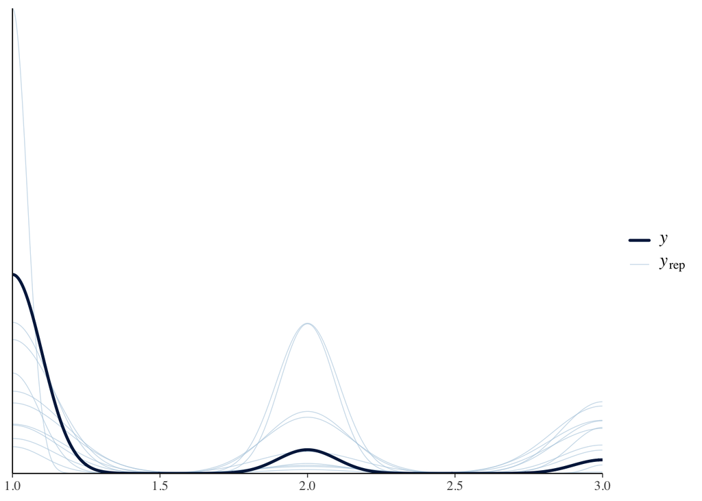

```r
# set weakly informative priors and do a prior predictive check
#fit_prior <- brm(shark_maxn ~  mpa_present + mpa_age + mpa_area + mpa_compliance +
 #                  gear_limits + species_limits + catch_limits + effort_limits + size_limits + temporal_limits + HDI_2015 + gov_effect_2016 + population_2016 + shark_protection_status + Grav_Total + (1|location_id/reef_id/set_id), #+ shark_sanctuary +
  #               prior = c(prior(normal(0, 4), class = Intercept),
   #                        prior(normal(0, 2), class = b),
    #                       prior(exponential(1), class = sd)),
     #            data = dat, family = sratio("cloglog"),
      #           iter = 4000, warmup = 1000, cores = 4, chains = 4, thin = 1,
       #          control = list(max_treedepth = 15, adapt_delta = 0.99),
        #         sample_prior = "only")

load(file = "outputs/models/ordinal-test_coral-triangle_v2.rda")
pp_check(fit_prior)
```

##### Fit the model with data

**Note** we can fit category-specific effects for covariates where we expect there would be different effects on the probability of encountering 0, 1, or more sharks.

```r
#fit <- brm(shark_maxn ~  mpa_present + mpa_age + mpa_area + mpa_compliance +
 #            gear_limits + species_limits + catch_limits + effort_limits + size_limits + temporal_limits + HDI_2015 + gov_effect_2016 + population_2016 + shark_protection_status + Grav_Total + (1|location_id/reef_id/set_id), #+ shark_sanctuary +
  #         prior = c(prior(normal(0, 4), class = Intercept),
   #                  prior(normal(0, 2), class = b),
    #                 prior(exponential(1), class = sd)),
     #      iter = 4000, warmup = 1000, cores = 4, chains = 4, thin = 1,
      #     data = dat, family = sratio("cloglog"),
       #    control = list(max_treedepth = 15, adapt_delta = 0.99))
# save models
#save(fit_prior, fit, dat, file = "outputs/models/ordinal-test_coral-triangle_v2.rda")
```

**Warning messages:** 1: There were 3 chains where the estimated Bayesian Fraction of Missing Information was low. See https://mc-stan.org/misc/warnings.html#bfmi-low 2: Examine the pairs() plot to diagnose sampling problems

3: Bulk Effective Samples Size (ESS) is too low, indicating posterior means and medians may be unreliable. Running the chains for more iterations may help. See https://mc-stan.org/misc/warnings.html#bulk-ess

Based on warnings we won’t make inferences yet, but should be ok to continue developing model before final run on full data.

##### Check model convergence and fit

Get a summary of the fitted model.

```r
summary(fit)
```

```
 Family: sratio
  Links: mu = cloglog; disc = identity
Formula: shark_maxn ~ mpa_present + mpa_age + mpa_area + mpa_compliance + gear_limits + species_limits + catch_limits + effort_limits + size_limits + temporal_limits + HDI_2015 + gov_effect_2016 + population_2016 + shark_protection_status + Grav_Total + (1 | location_id/reef_id/set_id)
   Data: dat (Number of observations: 2560)
  Draws: 4 chains, each with iter = 4000; warmup = 1000; thin = 1;
         total post-warmup draws = 12000

Multilevel Hyperparameters:
~location_id (Number of levels: 8)
              Estimate Est.Error l-95% CI u-95% CI Rhat Bulk_ESS Tail_ESS
sd(Intercept)     2.19      0.92     0.83     4.40 1.00     1687     4238

~location_id:reef_id (Number of levels: 50)
              Estimate Est.Error l-95% CI u-95% CI Rhat Bulk_ESS Tail_ESS
sd(Intercept)     1.05      0.36     0.50     1.89 1.02      346     1064

~location_id:reef_id:set_id (Number of levels: 2560)
              Estimate Est.Error l-95% CI u-95% CI Rhat Bulk_ESS Tail_ESS
sd(Intercept)     2.21      0.72     0.97     3.74 1.02      247      521

Regression Coefficients:
                                  Estimate Est.Error l-95% CI u-95% CI Rhat
Intercept[1]                          1.56      1.40    -0.97     4.54 1.00
Intercept[2]                          3.34      1.78     0.26     7.20 1.01
mpa_present1                         -0.39      0.91    -2.19     1.42 1.00
mpa_age                              -0.89      0.70    -2.37     0.45 1.00
mpa_area                              1.67      0.79     0.29     3.38 1.00
mpa_compliance1                       1.18      0.94    -0.53     3.18 1.00
gear_limits1                         -0.39      0.83    -1.95     1.40 1.00
species_limits1                      -0.11      0.96    -2.11     1.70 1.00
catch_limits1                         0.72      1.64    -2.44     3.95 1.00
effort_limits1                        1.85      0.78     0.54     3.60 1.01
size_limits1                          0.70      1.66    -2.54     3.96 1.00
temporal_limits1                      0.01      1.43    -2.83     2.83 1.00
HDI_2015                             -1.22      1.57    -4.30     1.91 1.00
gov_effect_2016                      -0.39      1.51    -3.41     2.54 1.00
population_2016                      -1.32      1.27    -3.86     1.15 1.00
shark_protection_statusopen          -1.80      1.09    -3.95     0.39 1.00
shark_protection_statusrestricted    -1.87      0.87    -3.65    -0.25 1.00
Grav_Total                           -0.58      0.37    -1.41     0.04 1.00
```

[output cut: 12 more lines]

```
temporal_limits1                      7579     8243
HDI_2015                              7984     8508
gov_effect_2016                       7465     8459
population_2016                       7248     7725
shark_protection_statusopen           4216     5746
shark_protection_statusrestricted     3165     5175
Grav_Total                            1663     3722

Further Distributional Parameters:
     Estimate Est.Error l-95% CI u-95% CI Rhat Bulk_ESS Tail_ESS
disc     1.00      0.00     1.00     1.00   NA       NA       NA

Draws were sampled using sampling(NUTS). For each parameter, Bulk_ESS
and Tail_ESS are effective sample size measures, and Rhat is the potential
scale reduction factor on split chains (at convergence, Rhat = 1).
```

Visual check of the posteriors and mcmc sampling.

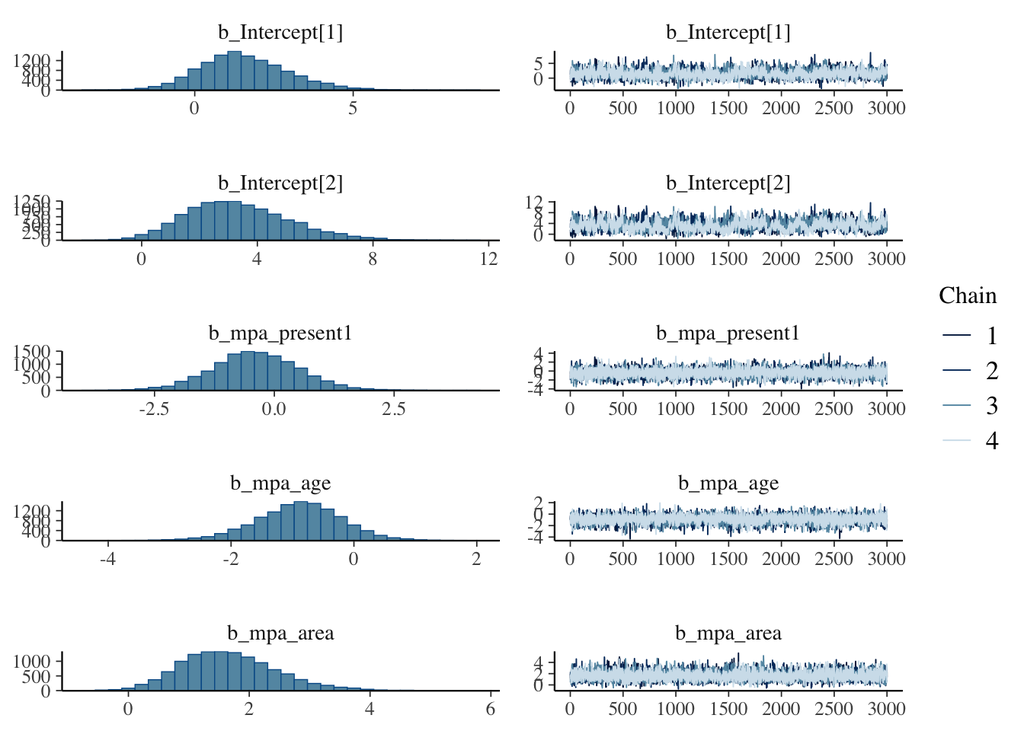

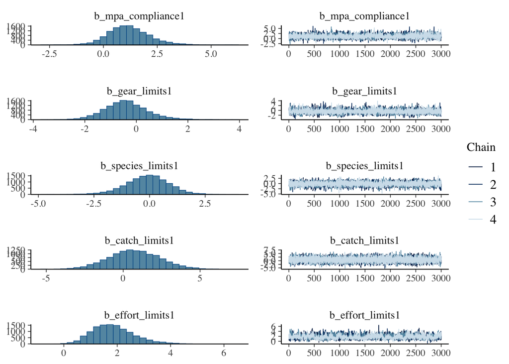

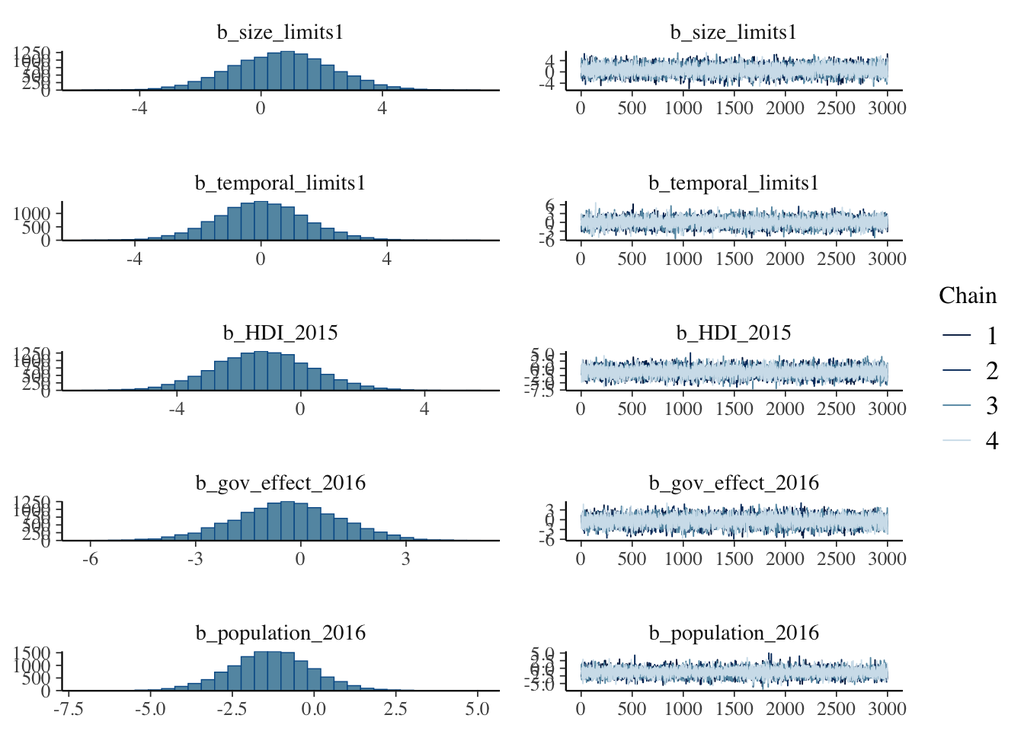

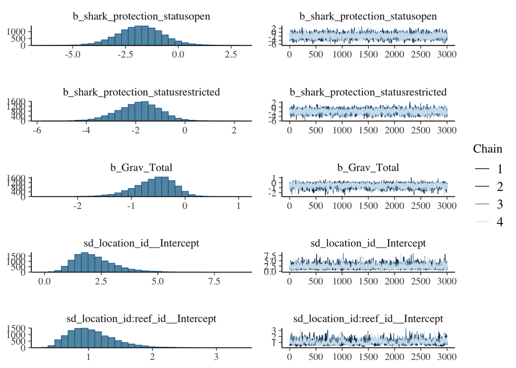

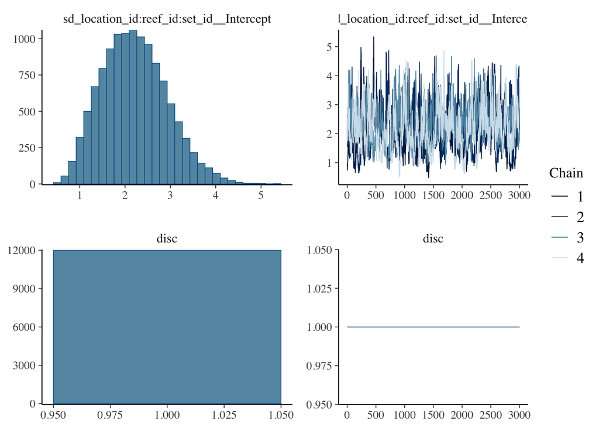

```r
plot(fit)
```

Posterior predictive check.

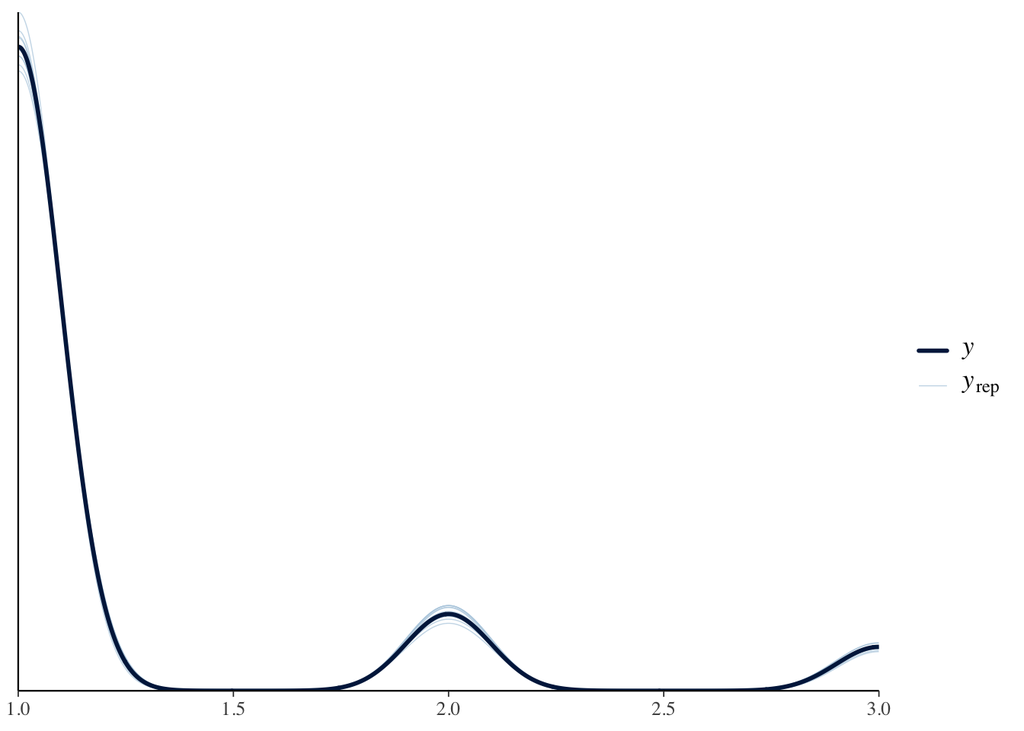

```r
pp_check(fit)
```

Check the residuals.

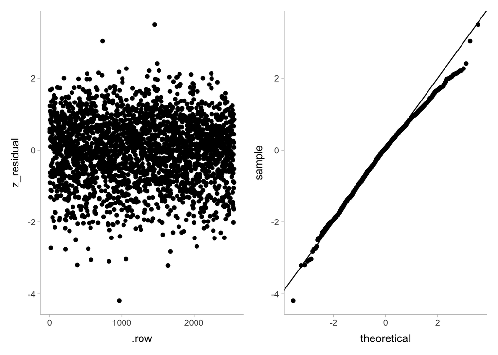

```r
library(patchwork)
library(tidybayes)
library(ggplot2)
theme_set(theme_tidybayes())

rq_resids <- dat |> # calculate randomised quantile residuals
  dplyr::select(-c(set_lat:set_long, region_id)) |>
  add_predicted_draws(fit, ndraws = 100) |> # note lower number of draws - takes ages otherwise
  mutate(.prediction = ordered(levels(shark_maxn)[.prediction], levels = levels(shark_maxn))) |>
  summarise(
    p_lower = mean(.prediction < shark_maxn),
    p_upper = mean(.prediction <= shark_maxn),
    p_residual = runif(1, p_lower, p_upper),
    z_residual = qnorm(p_residual))
#save(rq_resids, file = "outputs/ordinal-test_coral-triangle_v2_resids.rda")
#load("outputs/ordinal-test_coral-triangle_v2_resids.rda")

a <- rq_resids |>
  ggplot(aes(x = .row, y = z_residual)) +
  geom_point()

b <- rq_resids |>
  ggplot(aes(sample = z_residual)) +
  geom_qq() +
  geom_abline()

a + b
```

**TODO** map out the residuals to get an indication of spatial autocorrelation

##### Plot coefficients and any interesting conditional effects

Plot the coefficients.

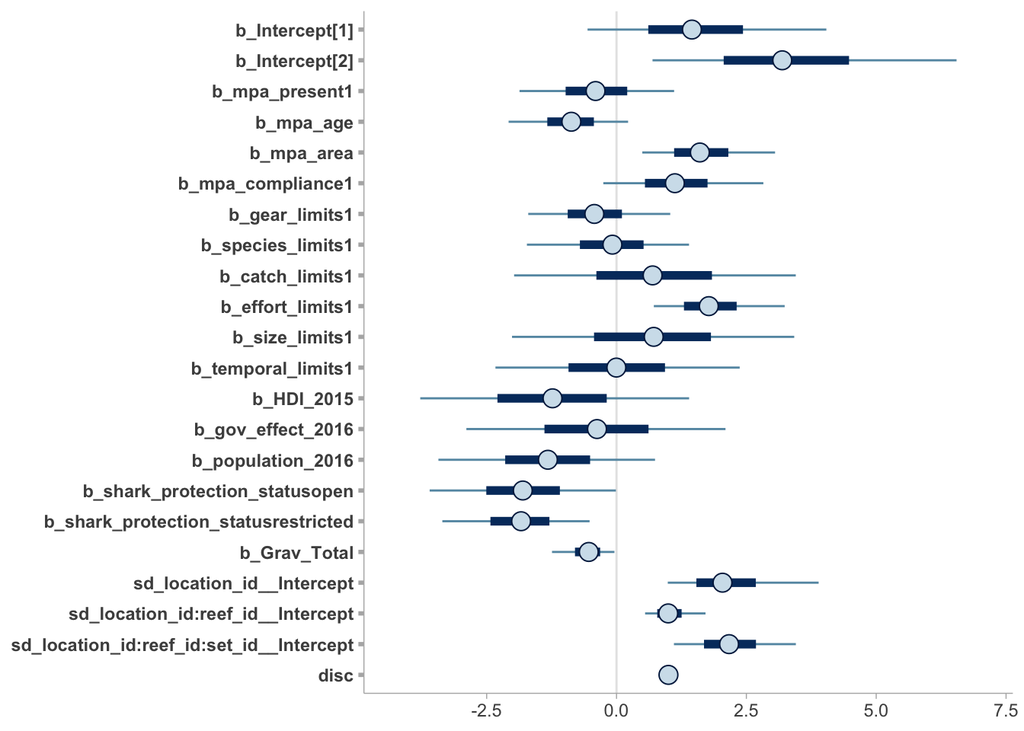

```r
mcmc_plot(fit)
```

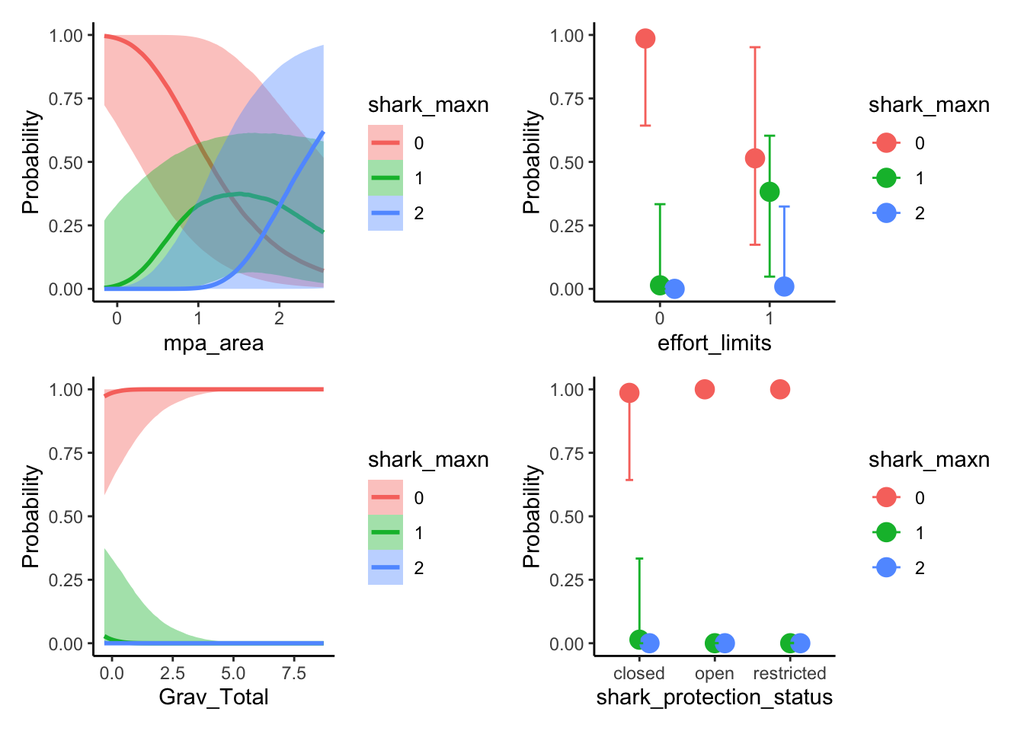

```r
# note plotting 75% credible intervals here
a <- plot(conditional_effects(fit, effects = 'mpa_area', categorical = T, prob = c(0.75)), plot = FALSE)[[1]] + theme_classic()
b <- plot(conditional_effects(fit, effects = 'effort_limits', categorical = T, prob = c(0.75)), plot = FALSE)[[1]] + theme_classic()
c <- plot(conditional_effects(fit, effects = 'Grav_Total', categorical = T, prob = c(0.75)), plot = FALSE)[[1]] + theme_classic()
d <- plot(conditional_effects(fit, effects = 'shark_protection_status', categorical = T, prob = c(0.75)), plot = FALSE)[[1]] + theme_classic()

(a+b)/(c+d)
```

##### Make counterfactual predictions

First try a management scenario where effort limits are enforced everywhere, and compare cumulative probability

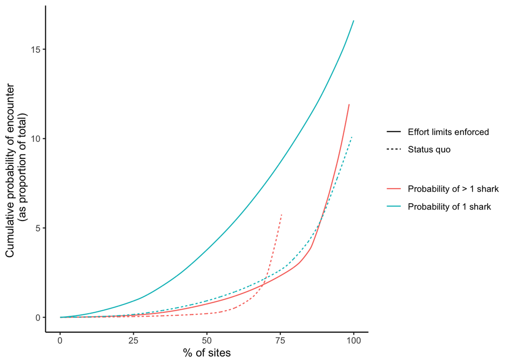

```r
# TODO: figure out how to use tidybayes to more easily wrangle predictions and their uncertainty

# new scenario data
effort_scenario <- dat |>
  mutate(effort_limits = 1)

# make predictions and summarise probability of each ordinal outcome at each site
base_preds <- fit |>
  posterior_predict(ndraws = 1000, cores = 4)

colnames(base_preds) <- dat$set_id

base_preds_prob <- base_preds |>
  data.frame() |>
  pivot_longer(everything(), names_to = 'set_id', values_to = 'shark_maxn') |>
  group_by(set_id, shark_maxn) |>
  summarise(predicted_prob = n()/1000) |>
  mutate(scenario = 'Status quo')
# number of draws (to save time - do all draws for final run)
ndraw <- 1000

effort_preds <- fit |>
  posterior_predict(newdata = effort_scenario, ndraws = ndraw, cores = 4)
colnames(effort_preds) <- dat$set_id

effort_preds_prob <- effort_preds |>
  data.frame() |>
  pivot_longer(everything(), names_to = 'set_id', values_to = 'shark_maxn') |>
  group_by(set_id, shark_maxn) |>
  summarise(predicted_prob = n()/ndraw) |>
  mutate(scenario = 'Effort limits enforced')
preds_prob <- bind_rows(base_preds_prob, effort_preds_prob)

# plot the cumulative probability of seeing 1 shark or more than one shark under scenarios
nsites <- length(unique(preds_prob$set_id))

preds_prob |>
  filter(shark_maxn != 1) |>
  group_by(scenario, shark_maxn) |>
  arrange(predicted_prob) |>
  mutate(cumulative_probability_encounter = (cumsum(predicted_prob)/nsites)*100,
         percent_sites = ((1:n())/nsites)*100,
         shark_maxn = ifelse(shark_maxn == 2, 'Probability of 1 shark', 'Probability of > 1 shark')) |>
  ggplot() +
  aes(x = percent_sites, y = cumulative_probability_encounter, col = factor(shark_maxn), lty = scenario) +
  geom_line() +
  ylab('Cumulative probability of encounter \n (as proportion of total)') +
  xlab('% of sites') +
  theme_classic() +
  theme(legend.title = element_blank())
```

#### Next steps

1. Fit full model to all data, one with and without an interaction with human gravity, compare models with loo cv and WAIC. Also perhaps try making human gravity binary (e.g., high vs. low)
2. Check for spatial autocorrelation in residuals
3. Make counterfactual predictions under management/conservation scenarios